# Semi-supervised and generative models

### Exercise 9.3 - Model Inference

Once trained, we can obtain new data points by sampling from the noise distribution.

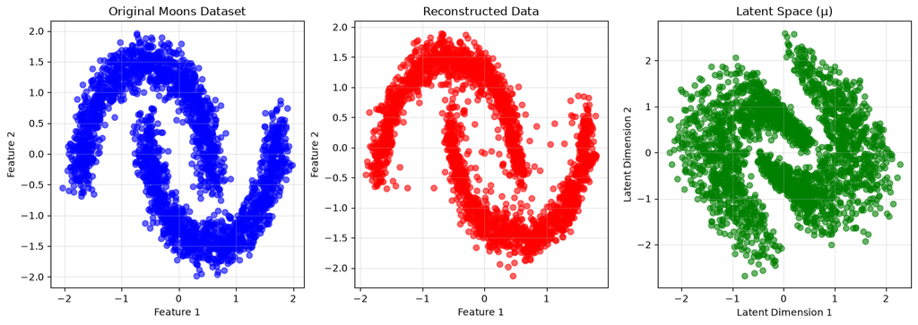

```python
with torch.no_grad():
    X_tensor = torch.tensor(X, dtype=torch.float32)
    x_hat, mu, logvar = vae.forward(X_tensor)

x_hat, mu = x_hat.numpy(), mu.numpy()

fig, axes = plt.subplots(1, 3, figsize=(16, 5))
axes[0].scatter(X[:, 0], X[:, 1], c='blue', alpha=0.6)
axes[0].set_title('Original Moons Dataset')
axes[0].set_xlabel('Feature 1')
axes[0].set_ylabel('Feature 2')
axes[0].grid(True, alpha=0.3)

axes[1].scatter(x_hat[:, 0], x_hat[:, 1], c='red', alpha=0.6)
axes[1].set_title('Reconstructed Data')
axes[1].set_xlabel('Feature 1')
axes[1].set_ylabel('Feature 2')
axes[1].grid(True, alpha=0.3)

# Latent space representation
axes[2].scatter(mu[:, 0], mu[:, 1], c='green', alpha=0.6)
axes[2].set_title('Latent Space (μ)')
axes[2].set_xlabel('Latent Dimension 1')
axes[2].set_ylabel('Latent Dimension 2')
axes[2].grid(True, alpha=0.3)
```

**(d) Sampling data from noise:**

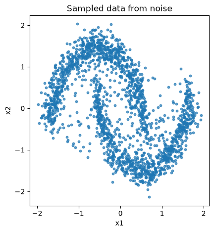

```python
@torch.no_grad()
def vae_sampling(n_samples=2000):
    # sample n_samples latent variables from the prior p(z) and decode them
    samples = ...
    z = torch.randn(n_samples, 2).to(device)
    samples = vae.decode(z)
    return samples

samples = vae_sampling()
plot_moons(samples, title="Sampled data from noise")
```

### Exercise 9.4 - Challenge Problem: How tight is the ELBO?

In Exercise 9.1 we showed that the ELBO is a *lower bound* on the log-likelihood $\log p_\theta(x)$, and in Exercise 9.2 we trained the VAE by maximizing this bound. But how far below $\log p_\theta(x)$ is the bound? In general we can not answer this question, since $p_\theta(x) = \int p_\theta(x|z) p(z) dz$ is intractable. Our VAE, however, has a *two-dimensional* latent space, so we can compute the integral accurately by numerical integration on a grid. We use this to measure the gap between the ELBO and the log-likelihood, and to study a tighter bound, the importance weighted ELBO ([Burda et al., 2016](https://arxiv.org/abs/1509.00519)).

Throughout, we use the model `vae` that was trained in Exercise 9.2. Its loss `elbo_loss` is, up to a constant and a factor $\beta$, the negative ELBO (estimated with a single sample) for the likelihood $$ p_\theta(x|z) = \prod_{d=1}^{2} \frac{1}{2b} \exp\left(-\frac{|x_d - f_\theta(z)_d|}{b}\right), \qquad b = \beta = 0.1, $$ i.e., each coordinate of $x$ follows a [Laplace distribution](https://en.wikipedia.org/wiki/Laplace_distribution) with location given by the decoder output $f_\theta(z)$ (`model.decode(z)`) and scale $b$. The log-densities of the model are implemented below.

```python
b = 0.1 # scale of the Laplace likelihood (equal to beta in Exercise 9.2)

def log_prior(z):
    # log N(z; 0, I)
    return -0.5 * (z**2 + np.log(2 * np.pi)).sum(dim=-1)

def log_q(z, mu, logvar):
    # log N(z; mu, diag(exp(logvar)))
    return -0.5 * ((z - mu)**2 / logvar.exp() + logvar + np.log(2 * np.pi)).sum(dim=-1)

def log_likelihood_laplace(x, x_hat, b):
    # log p(x | z) where x_hat = decode(z)
    return (-np.log(2 * b) - (x - x_hat).abs() / b).sum(dim=-1)
```

#### (a) The gap between the ELBO and the log-likelihood

*(Pen and paper exercise)* Show that for every $x$ $$ \log p_\theta(x) - \mathcal{L}(x; \theta, \phi) = D_{KL}(q_\phi(z|x) \| p_\theta(z|x)), $$ where $p_\theta(z|x) = p_\theta(x|z) p(z) / p_\theta(x)$ is the true posterior of the model. When is the ELBO tight?

We now compute $\log p_\theta(x)$ numerically. For a grid of $G \times G$ points $z_{ij} = (g_i, g_j)$, where $g_1, \ldots, g_G$ are equally spaced in $[-L, L]$ with spacing $\Delta$, we approximate $$ p_\theta(x) \approx \Delta^2 \sum_{i=1}^G \sum_{j=1}^G p_\theta(x|z_{ij}) p(z_{ij}). $$ Implement the function `log_marginal_quadrature` that returns $\log p_\theta(x_n)$ for every row $x_n$ of `x`. Why do we have to compute the sum in log-space with [`torch.logsumexp`](https://pytorch.org/docs/stable/generated/torch.logsumexp.html)?

*Hint*: The grid only needs to be decoded once. To save memory, the data points are processed in batches.

```python
@torch.no_grad()
def log_marginal_quadrature(model, x, b, L=5.0, G=300, batch_size=100):
    # grid of G x G points in [-L, L]^2 and the log of the area of a grid cell
    grid = torch.linspace(-L, L, G, device=x.device)
    z_grid = torch.cartesian_prod(grid, grid) # shape (G*G, 2)
    log_dz = 2 * torch.log(grid[1] - grid[0])
    x_hat_grid = model.decode(z_grid) # shape (G*G, 2)

    log_px = []
    for x_batch in x.split(batch_size):
        # log p(x_n) for all data points in the batch, shape (batch_size,)
        log_px_batch = ...
        log_joint = log_likelihood_laplace(x_batch[:, None, :], x_hat_grid, b) + log_prior(z_grid)
        log_px_batch = torch.logsumexp(log_joint, dim=1) + log_dz
        log_px.append(log_px_batch)
    return torch.cat(log_px)
```

The following code compares the average log-likelihood with the average ELBO, estimated with 100 samples from $q_\phi(z|x)$ for every data point, and shows the gap for every data point.

```
log-likelihood: -1.9718
ELBO:           -2.2557
```

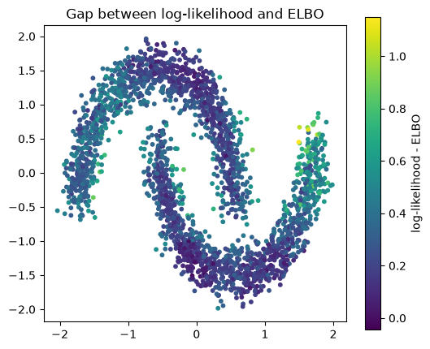

```python
X_tensor = torch.tensor(X, dtype=torch.float32, device=device)

@torch.no_grad()
def elbo_estimate(model, x, b, n_samples=100):
    # Monte Carlo estimate of the ELBO of each data point
    mu, logvar = model.encode(x)
    z = mu + torch.exp(0.5 * logvar) * torch.randn(n_samples, *mu.shape, device=x.device)
    log_w = log_likelihood_laplace(x, model.decode(z), b) + log_prior(z) - log_q(z, mu, logvar)
    return log_w.mean(dim=0)

torch.manual_seed(0)
log_px_vae = log_marginal_quadrature(vae, X_tensor, b)
elbo_vae = elbo_estimate(vae, X_tensor, b)
print(f"log-likelihood: {log_px_vae.mean().item():.4f}")
print(f"ELBO:           {elbo_vae.mean().item():.4f}")

gap = (log_px_vae - elbo_vae).cpu().numpy()
plt.figure(figsize=(6, 5))
plt.scatter(X[:, 0], X[:, 1], c=gap, s=10, cmap="viridis")
plt.colorbar(label="log-likelihood - ELBO")
plt.gca().set_aspect("equal", adjustable="box")
plt.title("Gap between log-likelihood and ELBO")
plt.show()
```

We can also compare the approximate posterior $q_\phi(z|x)$ with the true posterior $p_\theta(z|x) \propto p_\theta(x|z) p(z)$, evaluated on a grid, for some data points. The red lines are the contours of $q_\phi(z|x)$ (corresponding to one and two standard deviations), and the filled contours show the true posterior.

Is the true posterior Gaussian? How does $q_\phi(z|x)$ differ from it? Explain your observation using the KL divergence in the gap.

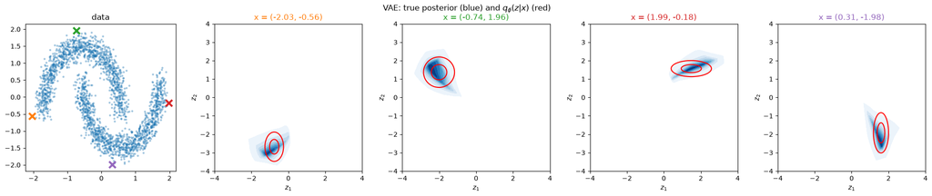

```python
# selected data points: both ends and the top of the moons
idx = [np.argmin(X[:, 0]), np.argmax(X[:, 1]), np.argmax(X[:, 0]), np.argmin(X[:, 1])]

@torch.no_grad()
def plot_posteriors(model, idx, title, L=4.0, G=250):
    grid = torch.linspace(-L, L, G, device=device)
    z_grid = torch.cartesian_prod(grid, grid)
    x_hat_grid = model.decode(z_grid)
    mu, logvar = model.encode(X_tensor[idx])
    grid = grid.cpu().numpy()

    fig, axes = plt.subplots(1, len(idx) + 1, figsize=(4 * (len(idx) + 1), 4))
    axes[0].scatter(X[:, 0], X[:, 1], s=5, alpha=0.3)
    axes[0].set_aspect("equal", adjustable="box")
    axes[0].set_title("data")
    for k, (n, ax) in enumerate(zip(idx, axes[1:])):
        axes[0].scatter(*X[n], color=f"C{k+1}", s=100, marker="x", linewidths=3)
        log_post = log_likelihood_laplace(X_tensor[n], x_hat_grid, b) + log_prior(z_grid)
        post = torch.exp(log_post - log_post.max()).reshape(G, G).T.cpu().numpy()
        log_q_grid = log_q(z_grid, mu[k], logvar[k])
        q_grid = torch.exp(log_q_grid - log_q_grid.max()).reshape(G, G).T.cpu().numpy()
        ax.contourf(grid, grid, post, levels=np.linspace(0.02, 1, 10), cmap="Blues", extend="neither")
        ax.contour(grid, grid, q_grid, levels=np.exp([-2, -0.5]), colors="red")
        ax.set_aspect("equal", adjustable="box")
        ax.set_xlabel("$z_1$")
        ax.set_ylabel("$z_2$")
        ax.set_title(f"x = ({X[n, 0]:.2f}, {X[n, 1]:.2f})", color=f"C{k+1}")
    fig.suptitle(title)
    plt.tight_layout()
    plt.show()

plot_posteriors(vae, idx, "VAE: true posterior (blue) and $q_\\phi(z|x)$ (red)")
```

**Solution:**

Using $p_\theta(x|z) p(z) = p_\theta(z|x) p_\theta(x)$, $$ \mathcal{L}(x; \theta, \phi) = \mathbb{E}_{q_\phi(z|x)}\left[\log \frac{p_\theta(z|x) p_\theta(x)}{q_\phi(z|x)}\right] = \log p_\theta(x) - \mathbb{E}_{q_\phi(z|x)}\left[\log \frac{q_\phi(z|x)}{p_\theta(z|x)}\right] = \log p_\theta(x) - D_{KL}(q_\phi(z|x) \| p_\theta(z|x)). $$ Hence the ELBO is tight if and only if $q_\phi(z|x) = p_\theta(z|x)$ (almost everywhere). Maximizing the ELBO with respect to $\phi$ is therefore the same as making $q_\phi(z|x)$ a good approximation of the true posterior, and maximizing it with respect to $\theta$ increases the log-likelihood *or* makes the true posterior easier to approximate by $q_\phi$.

#### (b) A tighter bound: importance weighting

For $K \geq 1$ we define the importance weighted ELBO $$ \mathcal{L}_K(x) = \mathbb{E}_{z_1, \ldots, z_K \sim q_\phi(z|x)}\left[\log \frac{1}{K} \sum_{k=1}^K w_k \right], \qquad w_k = \frac{p_\theta(x|z_k) p(z_k)}{q_\phi(z_k|x)}, $$ where $z_1, \ldots, z_K$ are sampled independently.

*(Pen and paper exercise)* Show that $\mathcal{L}_1(x)$ is the ELBO $\mathcal{L}(x; \theta, \phi)$ and that $\mathcal{L}_K(x) \leq \log p_\theta(x)$ for all $K$. (One can also show that $\mathcal{L}_K(x)$ increases monotonically with $K$ and converges to $\log p_\theta(x)$ as $K \to \infty$ under mild conditions, see Burda et al.)

Implement the function `iwae_bound(model, x, b, K)` that returns a Monte Carlo estimate of $\mathcal{L}_K(x_n)$ for every row $x_n$ of `x`, based on one set of $K$ samples $z_1, \ldots, z_K \sim q_\phi(z|x_n)$ (sampled with the reparameterization trick). Do *not* use `torch.no_grad()` inside the function, since we will train with it in (c).

Plot the average $\mathcal{L}_K$ for $K = 1, 2, 4, \ldots, 1024$ together with the average log-likelihood from (a). How many samples are needed to close half of the gap between the ELBO and the log-likelihood?

*Hint*: Use that $\log \frac{1}{K} \sum_{k=1}^K w_k = \operatorname{logsumexp}(\log w_1, \ldots, \log w_K) - \log K$.

```python
def iwae_bound(model, x, b, K):
    # estimate of the importance weighted ELBO L_K(x_n) for every data point, shape (N,)
    L_K = ...
    mu, logvar = model.encode(x)
    z = mu + torch.exp(0.5 * logvar) * torch.randn(K, *mu.shape, device=x.device) # shape (K, N, 2)
    log_w = log_likelihood_laplace(x, model.decode(z), b) + log_prior(z) - log_q(z, mu, logvar) # shape (K, N)
    L_K = torch.logsumexp(log_w, dim=0) - np.log(K)
    return L_K
```

```
K =    1: -2.2629
K =    2: -2.1214
K =    4: -2.0571
K =    8: -2.0249
K =   16: -2.0079
K =   32: -1.9993
K =   64: -1.9881
K =  128: -1.9863
K =  256: -1.9810
K =  512: -1.9800
K = 1024: -1.9794
```

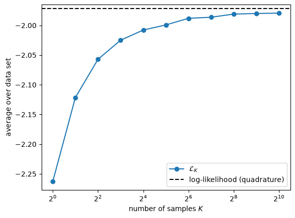

```python
@torch.no_grad()
def average_iwae_bound(model, x, b, K, repetitions=5, batch_size=100):
    # average of L_K over the data set (and over several repetitions to reduce the Monte Carlo error)
    return np.mean([
        torch.cat([iwae_bound(model, x_batch, b, K) for x_batch in x.split(batch_size)]).mean().item()
        for _ in range(repetitions)
    ])

torch.manual_seed(0)
Ks = 2 ** np.arange(11)
L_Ks = [average_iwae_bound(vae, X_tensor, b, K) for K in Ks]
for K, L_K in zip(Ks, L_Ks):
    print(f"K = {K:4d}: {L_K:.4f}")

plt.figure()
plt.semilogx(Ks, L_Ks, "o-", base=2, label="$\\mathcal{L}_K$")
plt.axhline(log_px_vae.mean().item(), color="k", linestyle="--", label="log-likelihood (quadrature)")
plt.xlabel("number of samples $K$")
plt.ylabel("average over data set")
plt.legend()
plt.show()
```

**Solution:**

1. For $K = 1$, $\mathcal{L}_1(x) = \mathbb{E}_{q_\phi(z|x)}[\log w_1] = \mathbb{E}_{q_\phi(z|x)}\left[\log \frac{p_\theta(x|z) p(z)}{q_\phi(z|x)}\right] = \mathcal{L}(x; \theta, \phi)$.
2. Every weight is an unbiased estimate of the marginal likelihood, $$ \mathbb{E}_{q_\phi(z|x)}[w_k] = \int q_\phi(z|x) \frac{p_\theta(x|z) p(z)}{q_\phi(z|x)} dz = p_\theta(x), $$ and hence so is their average. Since $\log$ is concave, Jensen's inequality gives $$ \mathcal{L}_K(x) = \mathbb{E}\left[\log \frac{1}{K} \sum_{k=1}^K w_k \right] \leq \log \mathbb{E}\left[\frac{1}{K} \sum_{k=1}^K w_k \right] = \log p_\theta(x). $$

Monotonicity in $K$ and convergence to $\log p_\theta(x)$ are shown in [Burda et al., 2016](https://arxiv.org/abs/1509.00519).

In the plot, $\mathcal{L}_K$ increases monotonically with $K$ and approaches the log-likelihood computed by quadrature, which confirms both our implementation of the quadrature and the theory. Already $K \approx 2$ to $4$ samples close half of the gap, but the convergence is slow afterwards: even with $K = 1024$ samples there is a small but visible gap. Note that for the closely related importance sampling estimate of $p_\theta(x)$ the variance of the weights matters - the narrower $q_\phi(z|x)$ is compared to the true posterior, the more samples are needed.

#### (c) Training with the tighter bound

Since $\mathcal{L}_K$ is a tighter bound on the log-likelihood than the ELBO, it is natural to train the model by maximizing $\mathcal{L}_K$ instead. This model is called the *importance weighted autoencoder* (IWAE). Note that it has exactly the same generative model and encoder as the VAE - only the training objective differs.

Implement the loss function `iwae_loss(model, x)`, the negative average of $\mathcal{L}_K$ with $K = 16$ over a mini-batch, and train a model with it (this takes a bit longer than in Exercise 9.2). Then compare the VAE and the IWAE: which one is the better generative model (larger $\log p_\theta(x)$), which one has the larger ELBO, and which encoder better approximates the true posterior?

*(Pen and paper exercise)* Explain your observations. *Hint*: What kind of distribution $q_\phi(z|x)$ makes the weights $w_k$ have low variance?

```python
def train_with_objective(loss_fn, epochs=200, lr=0.001, print_every=20, seed=0):
    torch.manual_seed(seed)
    model = VAE(dim=128).to(device)
    optimizer = torch.optim.Adam(model.parameters(), lr=lr)

    for epoch in range(1, epochs+1):
        for x, _ in loader:
            loss = loss_fn(model, x.to(device))
            optimizer.zero_grad()
            loss.backward()
            optimizer.step()
        if epoch % print_every == 0:
            print(f"Epoch: {epoch} | loss: {loss.item():.4f}")

    return model
```

```python
def iwae_loss(model, x):
    # negative average of the importance weighted ELBO with K = 16
    loss = ...
    loss = -iwae_bound(model, x, b, K=16).mean()
    return loss

iwae = train_with_objective(iwae_loss)
```

```
Epoch: 20 | loss: 2.2710
Epoch: 40 | loss: 2.0482
Epoch: 60 | loss: 2.2899
Epoch: 80 | loss: 1.9190
Epoch: 100 | loss: 2.1398
Epoch: 120 | loss: 2.0304
Epoch: 140 | loss: 1.9861
Epoch: 160 | loss: 2.2305
Epoch: 180 | loss: 1.8800
Epoch: 200 | loss: 2.0542
```

```
VAE  | log-likelihood: -1.9718 | L_16: -2.0045 | ELBO: -2.2569
IWAE | log-likelihood: -1.8895 | L_16: -1.9587 | ELBO: -3.7687
```

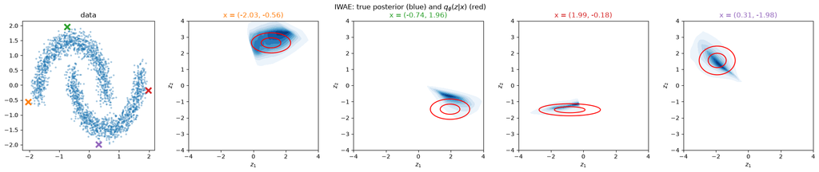

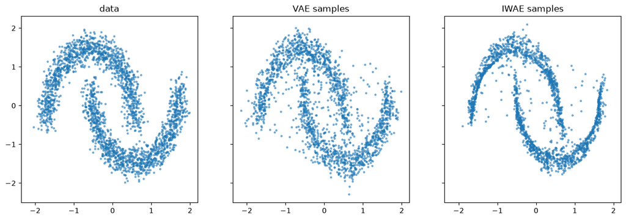

```python
torch.manual_seed(0)
for name, model in [("VAE", vae), ("IWAE", iwae)]:
    print(f"{name:4s} | log-likelihood: {log_marginal_quadrature(model, X_tensor, b).mean().item():.4f}"
          f" | L_16: {average_iwae_bound(model, X_tensor, b, K=16):.4f}"
          f" | ELBO: {elbo_estimate(model, X_tensor, b).mean().item():.4f}")

plot_posteriors(iwae, idx, "IWAE: true posterior (blue) and $q_\\phi(z|x)$ (red)")

# compare samples (decoder outputs for z ~ N(0, I)) of both models
with torch.no_grad():
    z = torch.randn(2000, 2, device=device)
    samples_vae = vae.decode(z).cpu().numpy()
    samples_iwae = iwae.decode(z).cpu().numpy()
fig, axes = plt.subplots(1, 3, figsize=(15, 5), sharex=True, sharey=True)
for ax, data, title in zip(axes, [X, samples_vae, samples_iwae], ["data", "VAE samples", "IWAE samples"]):
    ax.scatter(data[:, 0], data[:, 1], s=5, alpha=0.5)
    ax.set_aspect("equal", adjustable="box")
    ax.set_title(title)
plt.show()
```

**Solution:**

The IWAE achieves a (slightly) larger log-likelihood than the VAE, and a $\mathcal{L}_{16}$ that is as large or larger, i.e., training with the tighter bound gives a (slightly) better generative model. However, the ELBO of the IWAE is *much* smaller than that of the VAE (in our runs about $-3.8$ compared to $-2.3$, while the log-likelihoods are about $-1.89$ and $-1.97$). By (a), the gap between log-likelihood and ELBO is $D_{KL}(q_\phi(z|x) \| p_\theta(z|x))$, so the encoder of the IWAE is a much *worse* approximation of the true posterior in the sense of this KL divergence. The posterior plots show why: the approximate posteriors of the IWAE are considerably wider than the true posteriors (and not even centered on them), whereas the approximate posteriors of the VAE are too narrow and concentrate on the core of the true posteriors. The samples of the IWAE also follow the moons more closely (note that we plot the decoder outputs $f_\theta(z)$ without the Laplace noise).

Explanation: For large $K$, $\mathcal{L}_K$ approaches $\log p_\theta(x)$ *for any* $q_\phi$ (with bounded weights), so the objective puts less and less pressure on $q_\phi$ to approximate the true posterior. Instead, $q_\phi$ only serves as a *proposal distribution* for importance sampling: the bound is tight if the average $\frac{1}{K} \sum_k w_k$ has small variance. If $q_\phi(z|x)$ is narrower than the posterior, some regions with large posterior density are rarely sampled and produce huge weights $w_k = p_\theta(x|z_k)p(z_k)/q_\phi(z_k|x)$ when they are sampled, which leads to a large variance. A $q_\phi(z|x)$ that is somewhat *wider* than the posterior (mass-covering) only wastes a few samples in regions with small weights, which is harmless for $K = 16$ samples. This is the opposite of the mode-seeking behaviour of the reverse KL divergence in the ELBO, which heavily penalizes any $q_\phi$ mass outside of the posterior. For the decoder, the IWAE objective is less restrictive: it does not force the true posterior to be well approximated by a single Gaussian, which leaves more flexibility to fit the data and explains the larger log-likelihood.

Remark: a larger $K$ is not always better for training. [Rainforth et al. (2018)](https://arxiv.org/abs/1802.04537) showed that the signal-to-noise ratio of the gradient estimates of the encoder parameters $\phi$ *decreases* as $K$ grows, which is another manifestation of the reduced pressure on the encoder.